# Fitted distributions

09 October 2024, 09:13

### Elicited cumulative probabilities

| $x$ | $P(X\le x)$ |
| --- | --- |
| 0.15 | 0.05 |
| 1.33 | 0.50 |
| 5.46 | 0.95 |

**Note**: not all distributions have been fitted. The requirements for fitting each distribution are as follows.

- Normal, Student-t, skew normal: smallest elicited probability less than 0.4; largest elicited probability greater than 0.6.
- Log normal and log Student-t: finite lower limit; smallest elicited probability less than 0.4; largest elicited probability greater than 0.6.
- Gamma: finite lower limit; at least one elicited probability between 0 and 1.
- Beta : finite lower and upper limits; smallest elicited probability less than 0.4; largest elicited probability greater than 0.6.
- Mirror gamma: finite upper limit; at least one elicited probability between 0 and 1.
- Mirror log normal and mirror log Student-t: finite upper limit; smallest elicited probability less than 0.4; largest elicited probability greater than 0.6.

The judgements provided were as follows.

| judgement | value |
| --- | --- |
| lower limit | 0.00 |
| upper limit | Inf |
| smallest elicited probability | 0.05 |
| largest elicited probability | 0.95 |

### Distributions

All parameter values reported to 3 significant figures.

#### Normal

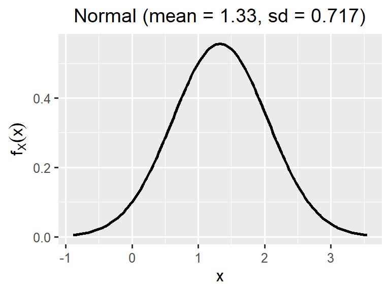

$$f_X(x)=\frac{1}{\sqrt{2\pi\sigma^2}}
\exp\left(-\frac{1}{2 \sigma^2}(x - \mu)^2\right),\quad
-\infty<x<\infty,$$
with
$$\mu =
1.33$$
$$\sigma^2 =
0.515$$

Sample `n = 1000` random values with the command

`rnorm(n = 1000, mean = 1.33, sd = sqrt(0.515))`

#### Student$-t$

$$f_X(x) = \frac{\Gamma((\nu + 1)/2)}{\Gamma(\nu/2)\sigma\sqrt{\nu \pi}}
\left(1 + \frac{1}{\nu}\left(\frac{x -
\mu}{\sigma}\right)^2\right)^{-(\nu + 1)/2},\quad
-\infty<x<\infty,$$
with
$$\nu = 3$$
$$\mu = 1.33$$
$$\sigma = 0.513$$

Sample `n = 1000` random values with the command

`1.33 + 0.513 * rt(n = 1000, df = 3)`

#### Skew normal

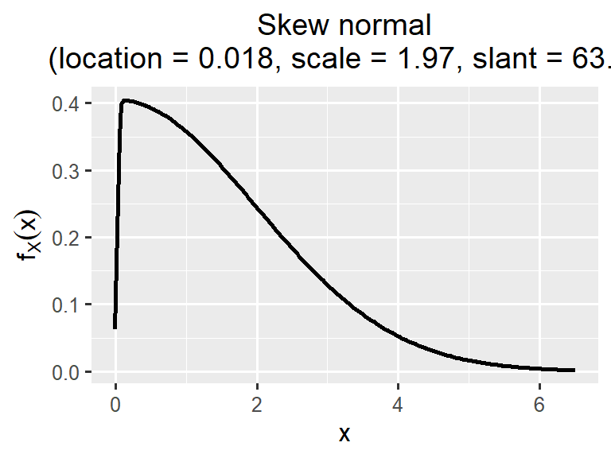

$$f_X(x)=\frac{2}{\omega}\phi\left(\frac{x-\xi}{\omega}\right)\Phi\left(\alpha\left(\frac{x-\xi}{\omega}\right)\right),\quad
-\infty<x<\infty,$$
where $\phi(.)$ and $\Phi(.)$ are the probability density function and cumulative distribution function respectively of the standard normal distribution, and with
$$\xi
= 0.018$$
$$\omega = 1.97$$
$$\alpha = 63.6$$

Sample `n = 1000` random values with the command

`sn::rsn(n = 1000, xi = 0.018, omega = 1.97, alpha = 63.6))`

#### Log normal

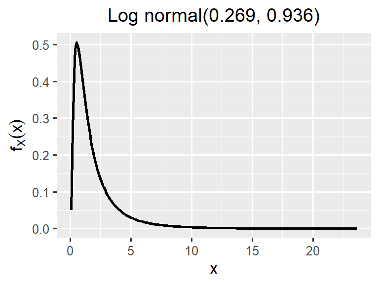

$$f_X(x) = \frac{1}{x} \times
\frac{1}{\sqrt{2\pi\sigma^2}}
\exp\left(-\frac{1}{2\sigma^2}(\ln x - \mu)^2\right), \quad x
>0$$
and $f_X(x)=0$ otherwise, with
$$\mu = 0.269$$
$$\sigma^2 = 0.876$$

Sample `n = 1000` random values with the command

`rlnorm(n = 1000, meanlog = 0.269, sdlog = sqrt(0.876))`

#### Gamma

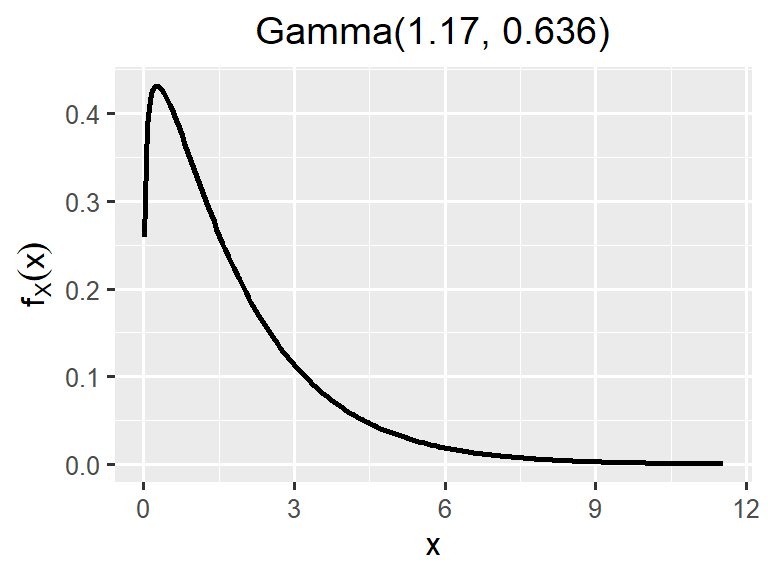

$$f_X(x) =\frac{\beta ^
{\alpha}}{\Gamma(\alpha)}x^{\alpha - 1} \exp\left(- \beta x\right),
\quad x >0$$
and $f_X(x)=0$ otherwise, with
$$\alpha = 1.17$$
$$\beta = 0.636$$

Sample `n = 1000` random values with the command

`rgamma(n = 1000, shape = 1.17, rate = 0.636)`

#### Log Student$-t$

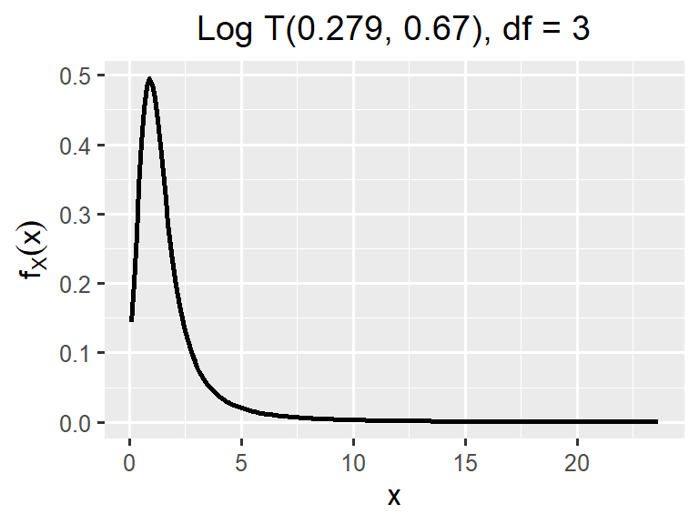

$$f_X(x) =\frac{1}{x} \times
\frac{\Gamma((\nu + 1)/2)}{\Gamma(\nu/2)\times\sigma\times \sqrt{\nu
\pi}} \left(1 + \frac{1}{\nu}\left(\frac{\ln x -
\mu}{\sigma}\right)^2\right)^{-(\nu + 1)/2}, \quad x >0$$
and $f_X(x)=0$ otherwise, with
$$\nu = 3$$
$$\mu = 0.279$$
$$\sigma = 0.67.$$

Sample `n = 1000` random values with the command

`exp(0.279 + 0.67 * rt(n = 1000, df = 3))`

#### Beta

Distribution not fitted.

#### Mirror gamma

Distribution not fitted.

#### Mirror Log normal

Distribution not fitted.

#### Mirror log Student$-t$

Distribution not fitted.